# Imbalanced Classes

Alexander Sirotkin

06 10 2017

На прошлом занятии вы работали с набором данных Caravan, при этом если вы не предпринимали никаких специальных действий, то вы легко получали очень “хорошую” модель с высоким accuracy.

Давайте попробуем вместе.

Начнем с разбиения на тестовую и обучающую выборки и построим модель классификации на основе дерева решений ctree.

```r
library(caret)
caravan = ISLR::Caravan
set.seed(18)

trainIndex <- createDataPartition(caravan$Purchase, p = .8,
                                  list = FALSE,
                                  times = 1)
CaravanTrain <- caravan[ trainIndex,]
CaravanTest  <- caravan[-trainIndex,]
```

Строим модель:

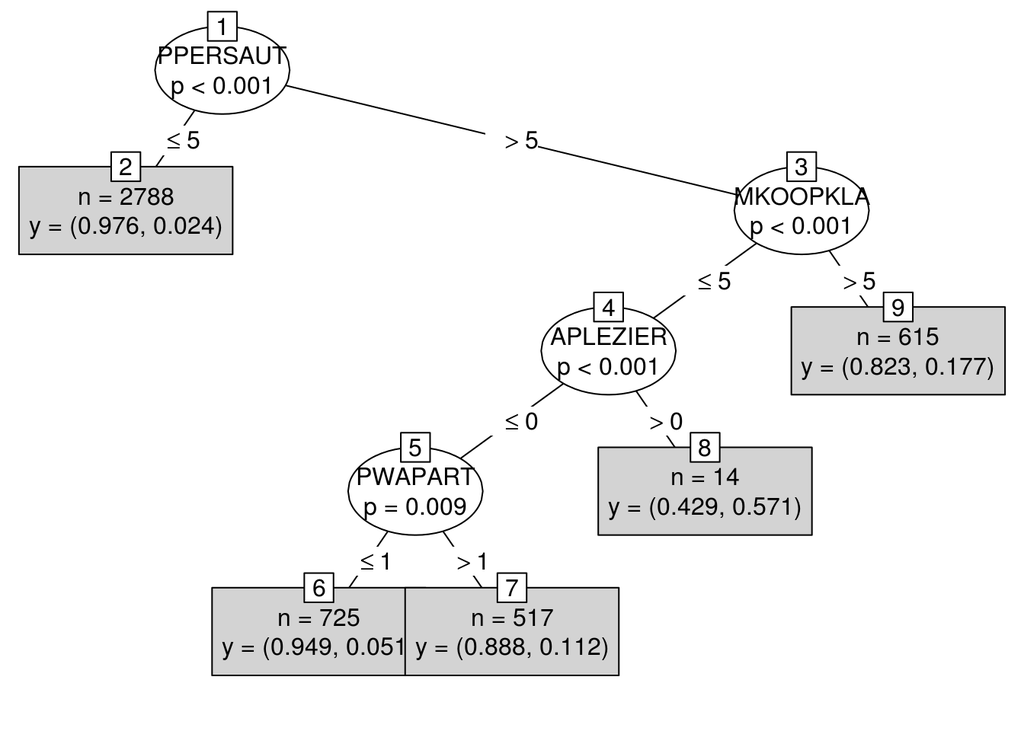

```r
cv5<-trainControl(method="cv", number = 5)
set.seed(100)
tree_model <- train(Purchase~., method = 'ctree', data = CaravanTrain, trControl=cv5)
plot(tree_model$finalModel, type="simple")
```

```r
predictions.on.train <- predict(tree_model, CaravanTrain)
#confusionMatrix(predictions.on.train, CaravanTrain$Purchase, positive = "Yes")
confusionMatrix(predictions.on.train, CaravanTrain$Purchase, positive = "Yes", mode = "prec_recall")
```

```
## Confusion Matrix and Statistics
##
##           Reference
## Prediction   No  Yes
##        No  4374  271
##        Yes    6    8
##
##                Accuracy : 0.9405
##                  95% CI : (0.9334, 0.9472)
##     No Information Rate : 0.9401
##     P-Value [Acc > NIR] : 0.4667
##
##                   Kappa : 0.0492
##  Mcnemar's Test P-Value : <2e-16
##
##               Precision : 0.571429
##                  Recall : 0.028674
##                      F1 : 0.054608
##              Prevalence : 0.059884
##          Detection Rate : 0.001717
##    Detection Prevalence : 0.003005
##       Balanced Accuracy : 0.513652
##
##        'Positive' Class : Yes
##
```

```r
predictions.on.test <- predict(tree_model, CaravanTest)
#confusionMatrix(predictions.on.test, CaravanTest$Purchase, positive = "Yes")
confusionMatrix(predictions.on.test, CaravanTest$Purchase, positive = "Yes", mode = "prec_recall")
```

```
## Confusion Matrix and Statistics
##
##           Reference
## Prediction   No  Yes
##        No  1094   68
##        Yes    0    1
##
##                Accuracy : 0.9415
##                  95% CI : (0.9265, 0.9543)
##     No Information Rate : 0.9407
##     P-Value [Acc > NIR] : 0.4825
##
##                   Kappa : 0.0269
##  Mcnemar's Test P-Value : 4.476e-16
##
##               Precision : 1.0000000
##                  Recall : 0.0144928
##                      F1 : 0.0285714
##              Prevalence : 0.0593293
##          Detection Rate : 0.0008598
##    Detection Prevalence : 0.0008598
##       Balanced Accuracy : 0.5072464
##
##        'Positive' Class : Yes
##
```

Мы все делали как положено, и получили accuracy >94% и на тренировочном датасете и на тесте, но очевидно, что это плохая модель. На тесте мы смогли правильно определить только один положительный пример.

Попробуем это исправить. Есть несколько способов сделать это:

1. Добавить веса: учитывать одну ошибку на слабо представленном классе, например, как десять ошибок на хорошо представленном классе.
2. Down-sampling: случайно выкинуть “лишние” данные из хорошо представленного класса.
3. Up-sampling: случайно добавить продублировав представителей слабопредставленного класса.
4. Synthetic minority sampling technique (SMOTE): сочетание Down-sampling и синтетических данных для слабо представленного класса на основе интерполяции.
- Подробнее можно почитать в статье [8 Tactics to Combat Imbalanced Classes in Your Machine Learning Dataset](https://machinelearningmastery.com/tactics-to-combat-imbalanced-classes-in-your-machine-learning-dataset/)
- А про реализацию в пакете `caret` [здесь](https://topepo.github.io/caret/subsampling-for-class-imbalances.html)

Давайте попробуем эти методы.

# Веса

Добавим веса к нашей модели. Для этого надо подготовить вектор, который для каждого примера укажет вес с которым учитывать ошибку именно на этом примере.

Важно отметить, что ctree допускает только целые веса. По сути, он рассматривает каждый пример как столько разных примеров какой вес ему назначен.

Глянем сколько у нас каких случаев.

```r
table(CaravanTrain$Purchase)
```

```
##
##   No  Yes
## 4380  279
```

```r
table(CaravanTrain$Purchase)[1]/table(CaravanTrain$Purchase)[2]
```

```
##       No
## 15.69892
```

```r
model_weights <- ifelse(CaravanTrain$Purchase == "No", 1, 15)
```

Теперь осталось только добавить полученные веса к нашей модели в процессе обучения.

[figure not shown]

```r
cv5$seeds<-tree_model$control$seeds
tree_model_weighted <- train(Purchase~., method = 'ctree', data = CaravanTrain, trControl=cv5, weights = model_weights)
plot(tree_model_weighted$finalModel, type="simple")
```

Обратите внимание на первую строчку. Она нужна, чтобы кросс валидация использовала то же разбиение что и в первом случае. Ну и как видно на картинке, модель стала заметно сложнее.

```r
w.on.train <- predict(tree_model_weighted, CaravanTrain)
confusionMatrix(w.on.train, CaravanTrain$Purchase, positive = "Yes")
```

```
## Confusion Matrix and Statistics
##
##           Reference
## Prediction   No  Yes
##        No  3652    0
##        Yes  728  279
##
##                Accuracy : 0.8437
##                  95% CI : (0.833, 0.8541)
##     No Information Rate : 0.9401
##     P-Value [Acc > NIR] : 1
##
##                   Kappa : 0.3753
##  Mcnemar's Test P-Value : <2e-16
##
##             Sensitivity : 1.00000
##             Specificity : 0.83379
##          Pos Pred Value : 0.27706
##          Neg Pred Value : 1.00000
##              Prevalence : 0.05988
##          Detection Rate : 0.05988
##    Detection Prevalence : 0.21614
##       Balanced Accuracy : 0.91689
##
##        'Positive' Class : Yes
##
```

```r
#confusionMatrix(w.on.train, CaravanTrain$Purchase, positive = "Yes", mode = "prec_recall")
```

Мы немного ухудшили Accuracy, но однозначно сильно улучшили Sensitivity (Recall). Но будет ли это работать на тестовой выборке.

```r
w.on.test <- predict(tree_model_weighted, CaravanTest)
#confusionMatrix(w.on.test, CaravanTest$Purchase, positive = "Yes")
confusionMatrix(w.on.test, CaravanTest$Purchase, positive = "Yes", mode = "prec_recall")
```

```
## Confusion Matrix and Statistics
##
##           Reference
## Prediction  No Yes
##        No  857  40
##        Yes 237  29
##
##                Accuracy : 0.7618
##                  95% CI : (0.7363, 0.786)
##     No Information Rate : 0.9407
##     P-Value [Acc > NIR] : 1
##
##                   Kappa : 0.0871
##  Mcnemar's Test P-Value : <2e-16
##
##               Precision : 0.10902
##                  Recall : 0.42029
##                      F1 : 0.17313
##              Prevalence : 0.05933
##          Detection Rate : 0.02494
##    Detection Prevalence : 0.22872
##       Balanced Accuracy : 0.60183
##
##        'Positive' Class : Yes
##
```

К сожалению, мы заметно потеряли в accurasy, да и Sensitivity (Recall) заметно упал. Возможно мы переобучились и стоит понастраивать вес как параметр модели. Но в любом случае, такая модель лучше исходной, так как исходная вообще почти не детектировала положительые случаи.

# Down-sampling

Попробуем повыкидывать “лишние” примеры. Это можно сделать руками, но caret о нас позаботился.

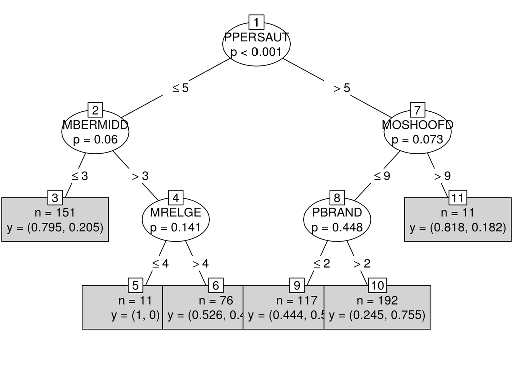

```r
cv5_down<-cv5
cv5_down$sampling<-"down"
tree_model_down <- train(Purchase~., method = 'ctree', data = CaravanTrain, trControl=cv5_down)
plot(tree_model_down$finalModel, type="simple")
```

Мы снова получили простую модель. А почему?

Посмотрим на ее качество.

```r
d.on.train <- predict(tree_model_down, CaravanTrain)
confusionMatrix(d.on.train, CaravanTrain$Purchase, positive = "Yes")
```

```
## Confusion Matrix and Statistics
##
##           Reference
## Prediction   No  Yes
##        No  2809   69
##        Yes 1571  210
##
##                Accuracy : 0.648
##                  95% CI : (0.6341, 0.6617)
##     No Information Rate : 0.9401
##     P-Value [Acc > NIR] : 1
##
##                   Kappa : 0.1119
##  Mcnemar's Test P-Value : <2e-16
##
##             Sensitivity : 0.75269
##             Specificity : 0.64132
##          Pos Pred Value : 0.11791
##          Neg Pred Value : 0.97603
##              Prevalence : 0.05988
##          Detection Rate : 0.04507
##    Detection Prevalence : 0.38227
##       Balanced Accuracy : 0.69701
##
##        'Positive' Class : Yes
##
```

```r
#confusionMatrix(d.on.train, CaravanTrain$Purchase, positive = "Yes", mode = "prec_recall")
```

А тут все стало сильно хуже. По сравнению с модельюгде мы использовали веса, совсем плохо и это на обучающей выборке. А почему так?

```r
d.on.test <- predict(tree_model_down, CaravanTest)
#confusionMatrix(d.on.test, CaravanTest$Purchase, positive = "Yes")
confusionMatrix(d.on.test, CaravanTest$Purchase, positive = "Yes", mode = "prec_recall")
```

```
## Confusion Matrix and Statistics
##
##           Reference
## Prediction  No Yes
##        No  681  20
##        Yes 413  49
##
##                Accuracy : 0.6277
##                  95% CI : (0.5992, 0.6555)
##     No Information Rate : 0.9407
##     P-Value [Acc > NIR] : 1
##
##                   Kappa : 0.0907
##  Mcnemar's Test P-Value : <2e-16
##
##               Precision : 0.10606
##                  Recall : 0.71014
##                      F1 : 0.18456
##              Prevalence : 0.05933
##          Detection Rate : 0.04213
##    Detection Prevalence : 0.39725
##       Balanced Accuracy : 0.66632
##
##        'Positive' Class : Yes
##
```

Что вы можете сказать, про этот вариант?

# Up sampling

[figure not shown]

```r
cv5_up<-cv5
cv5_up$sampling<-"up"
tree_model_up <- train(Purchase~., method = 'ctree', data = CaravanTrain, trControl=cv5_up)
plot(tree_model_up$finalModel, type="simple")
```

Посмотрим на качество модели.

```r
u.on.train <- predict(tree_model_up, CaravanTrain)
#confusionMatrix(u.on.train, CaravanTrain$Purchase, positive = "Yes")
confusionMatrix(u.on.train, CaravanTrain$Purchase, positive = "Yes", mode = "prec_recall")
```

```
## Confusion Matrix and Statistics
##
##           Reference
## Prediction   No  Yes
##        No  3661    0
##        Yes  719  279
##
##                Accuracy : 0.8457
##                  95% CI : (0.835, 0.8559)
##     No Information Rate : 0.9401
##     P-Value [Acc > NIR] : 1
##
##                   Kappa : 0.3788
##  Mcnemar's Test P-Value : <2e-16
##
##               Precision : 0.27956
##                  Recall : 1.00000
##                      F1 : 0.43696
##              Prevalence : 0.05988
##          Detection Rate : 0.05988
##    Detection Prevalence : 0.21421
##       Balanced Accuracy : 0.91792
##
##        'Positive' Class : Yes
##
```

На обучаещей выборке модель ведет себя прекрасно. А на тесте?

```r
u.on.test <- predict(tree_model_up, CaravanTest)
#confusionMatrix(u.on.test, CaravanTest$Purchase, positive = "Yes")
confusionMatrix(u.on.test, CaravanTest$Purchase, positive = "Yes", mode = "prec_recall")
```

```
## Confusion Matrix and Statistics
##
##           Reference
## Prediction  No Yes
##        No  849  43
##        Yes 245  26
##
##                Accuracy : 0.7524
##                  95% CI : (0.7265, 0.7769)
##     No Information Rate : 0.9407
##     P-Value [Acc > NIR] : 1
##
##                   Kappa : 0.0645
##  Mcnemar's Test P-Value : <2e-16
##
##               Precision : 0.09594
##                  Recall : 0.37681
##                      F1 : 0.15294
##              Prevalence : 0.05933
##          Detection Rate : 0.02236
##    Detection Prevalence : 0.23302
##       Balanced Accuracy : 0.57643
##
##        'Positive' Class : Yes
##
```

Что вы можете сказать, про этот вариант?

# SMOTE

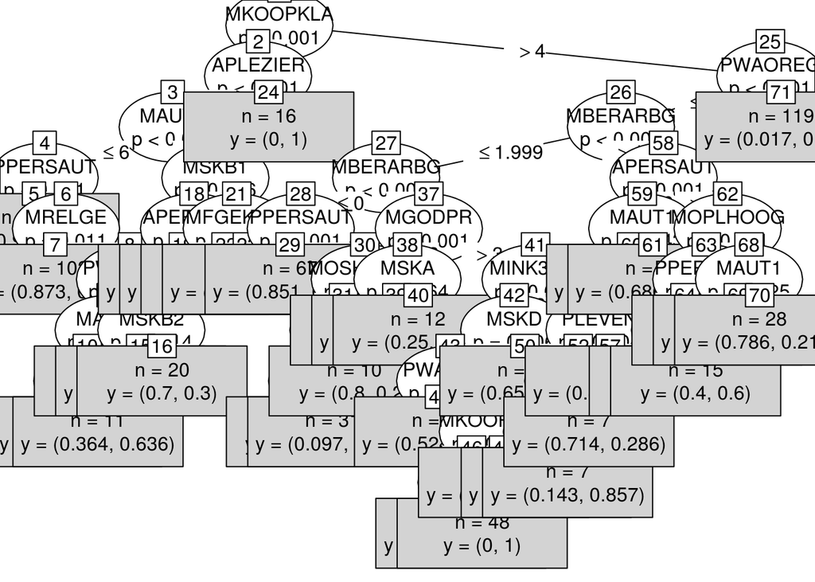

```r
cv5_smote<-cv5
cv5_smote$sampling<-"smote"
tree_model_smote <- train(Purchase~., method = 'ctree', data = CaravanTrain, trControl=cv5_smote)
plot(tree_model_smote$finalModel, type="simple")
```

А тут мы видим не очень сложную, но и не очень простую модель. Станет ли она золотой серединой?

```r
s.on.train <- predict(tree_model_smote, CaravanTrain)
#confusionMatrix(s.on.train, CaravanTrain$Purchase, positive = "Yes")
confusionMatrix(s.on.train, CaravanTrain$Purchase, positive = "Yes", mode = "prec_recall")
```

```
## Confusion Matrix and Statistics
##
##           Reference
## Prediction   No  Yes
##        No  3808  157
##        Yes  572  122
##
##                Accuracy : 0.8435
##                  95% CI : (0.8328, 0.8539)
##     No Information Rate : 0.9401
##     P-Value [Acc > NIR] : 1
##
##                   Kappa : 0.1808
##  Mcnemar's Test P-Value : <2e-16
##
##               Precision : 0.17579
##                  Recall : 0.43728
##                      F1 : 0.25077
##              Prevalence : 0.05988
##          Detection Rate : 0.02619
##    Detection Prevalence : 0.14896
##       Balanced Accuracy : 0.65334
##
##        'Positive' Class : Yes
##
```

```r
s.on.test <- predict(tree_model_smote, CaravanTest)
confusionMatrix(s.on.test, CaravanTest$Purchase, positive = "Yes")
```

```
## Confusion Matrix and Statistics
##
##           Reference
## Prediction  No Yes
##        No  928  48
##        Yes 166  21
##
##                Accuracy : 0.816
##                  95% CI : (0.7925, 0.8379)
##     No Information Rate : 0.9407
##     P-Value [Acc > NIR] : 1
##
##                   Kappa : 0.0847
##  Mcnemar's Test P-Value : 1.265e-15
##
##             Sensitivity : 0.30435
##             Specificity : 0.84826
##          Pos Pred Value : 0.11230
##          Neg Pred Value : 0.95082
##              Prevalence : 0.05933
##          Detection Rate : 0.01806
##    Detection Prevalence : 0.16079
##       Balanced Accuracy : 0.57631
##
##        'Positive' Class : Yes
##
```

```r
#confusionMatrix(s.on.test, CaravanTest$Purchase, positive = "Yes", mode = "prec_recall")
```

Какая модель понравилась вам больше всего?

*Ваша очередь:* рассмотрим небольшой датасет про переливание крови. Сможете ли вы предсказать, сдавал ли кровь человек в марте 2007 года? Тут есть небольшой дисбаланс в классах. Попробуйте применить к нему разные методы работы с дисбалансом и разные методы классификации.

```r
library(readr)
blood <- read_csv("~/shared/minor3_2017/3-SecondYear-ML/practice-4-class-imbalanced/blood.csv")
table(blood$`whether he/she donated blood in March 2007`)
```

```
##
##   0   1
## 570 178
```